# HealthCareAndCauseOfDeath_RStudio.Rmd

Herbert Gutierrez, Ryan Wechter, Varun Parameswaran

November 12, 2015

## Health Care Spending and Causes of Death by State

### CS329E: Project 5

In this project, we will duplicate our original Tableau visualizations in the HealthCareAndCauseOfDeath_Tableau.Rmd using R. Then, we used blending to bring in another state population dataset and create a fourth visualization in Tableau (blending was used here) and R (a join was used here).

#### RStudio Configuration:

## Loading our data from the Oracle Database

#### Dataset 1: National Healthcare Expediture

We modified the R script given to us to create a SQL code that would create the table in the Oracle Database. We then loaded our data and could connect to the database to create our data frame in RStudio.

```r
source("../01 Data/Project1T_ETL_Data1.R", echo = TRUE)
```

```
##
## > require("ggplot2")
##
## > require("gplots")
##
## > require("grid")
##
## > require("RCurl")
##
## > require("reshape2")
##
## > require("tableplot")
##
## > require("tidyr")
##
## > require("dplyr")
##
## > require("jsonlite")
##
## > require("lubridate")
##
## > NHCE <- data.frame(fromJSON(getURL(URLencode("skipper.cs.utexas.edu:5001/rest/native/?query=\"select * from NHCE\""),
## +     httpheader = c(DB = "jd ..." ... [TRUNCATED]
##
## > summary(NHCE)
##       CODE
##  Min.   : 1.000
##  1st Qu.: 3.000
##  Median : 6.000
##  Mean   : 6.009
##  3rd Qu.: 9.000
##  Max.   :12.000
##
##                                                                  ITEM
##  Dental Services (Millions of Dollars)                             : 60
##  Durable Medical Products (Millions of Dollars)                    : 60
##  Home Health Care (Millions of Dollars)                            : 60
##  Hospital Care (Millions of Dollars)                               : 60
##  Nursing Home Care (Millions of Dollars)                           : 60
##  Other Health, Residential, and Personal Care (Millions of Dollars): 60
```

[output cut: 133 more lines]

```
## 6   7426.551   8001.633   8413.042   9016.119   9656.318  10378.470
##        Y2002      Y2003      Y2004      Y2005      Y2006      Y2007
## 1   8509.315   9158.444   9878.918  10611.848  11433.561  11974.625
## 2   3661.127   3829.103   4116.249   4316.847   4573.038   4870.854
## 3   3867.730   4202.010   4412.996   4696.752   5040.251   5302.105
## 4 329482.812 355228.625 384733.406 409634.125 436078.531 459378.906
## 5  20099.266  22343.691  23497.984  25041.941  26263.139  27201.480
## 6  11349.469  12086.956  12913.167  13946.515  14725.488  15587.392
##        Y2008      Y2009 AVERAGE_ANNUAL_PERCENT_GROWTH
## 1  12473.312  12845.254                           7.9
## 2   5078.880   5408.336                           7.7
## 3   5629.931   5973.722                           8.4
## 4 480363.938 502481.500                           8.8
## 5  28159.199  29125.943                           7.9
## 6  16469.789  17129.988                           8.2
```

#### Dataset 2: National Cause of Death

```r
source("../01 Data/Project1T_ETL_Data2.R", echo = TRUE)
```

```
##
## > COD <- data.frame(fromJSON(getURL(URLencode("skipper.cs.utexas.edu:5001/rest/native/?query=\"select * from COD\""),
## +     httpheader = c(DB = "jdbc ..." ... [TRUNCATED]
##
## > summary(COD)
##                                              X113_CAUSE_NAME
##  Accidents (unintentional injuries) (V01-X59,Y85-Y86): 780
##  All Causes                                          : 780
##  Alzheimers disease (G30)                            : 780
##  Chronic liver disease and cirrhosis (K70,K73-K74)   : 780
##  Chronic lower respiratory diseases (J40-J47)        : 780
##  Diabetes mellitus (E10-E14)                         : 780
##  (Other)                                             :6802
##                                CAUSE_NAME             STATE
##  All Causes                         : 780   Wisconsin    :  239
##  Alzheimers disease                 : 780   United States:  237
##  Cancer                             : 780   Utah         :  237
##  Chronic liver disease and cirrhosis: 780   Washington   :  237
##  CLRD                               : 780   West Virginia:  237
##  Diabetes                           : 780   Tennessee    :  235
##  (Other)                            :6802   (Other)      :10060
##       YEAR          DEATHS             AADR
##  Min.   :1999   Min.   :     20   Min.   :   1.38
##  1st Qu.:2002   1st Qu.:    332   1st Qu.:   9.75
##  Median :2006   Median :    986   Median :  21.14
##  Mean   :2006   Mean   :  11537   Mean   :  97.94
##  3rd Qu.:2010   3rd Qu.:   3104   3rd Qu.:  49.68
##  Max.   :2013   Max.   :2596993   Max.   :1087.30
##
##
## > head(COD)
##                                        X113_CAUSE_NAME
## 1 Accidents (unintentional injuries) (V01-X59,Y85-Y86)
## 2 Accidents (unintentional injuries) (V01-X59,Y85-Y86)
## 3 Accidents (unintentional injuries) (V01-X59,Y85-Y86)
## 4 Accidents (unintentional injuries) (V01-X59,Y85-Y86)
## 5 Accidents (unintentional injuries) (V01-X59,Y85-Y86)
## 6 Accidents (unintentional injuries) (V01-X59,Y85-Y86)
##               CAUSE_NAME      STATE YEAR DEATHS  AADR
## 1 Unintentional Injuries    Alabama 1999   2313 52.17
## 2 Unintentional Injuries     Alaska 1999    294 55.91
## 3 Unintentional Injuries    Arizona 1999   2214 44.79
## 4 Unintentional Injuries   Arkansas 1999   1287 47.56
## 5 Unintentional Injuries California 1999   9198 28.71
## 6 Unintentional Injuries   Colorado 1999   1519 38.98
```

#### Dataset 3: State Populations 2000-2009

```r
source("../01 Data/Project1T_ETL_Data3.R", echo = TRUE)
```

```
##
## > require("ggplot2")
##
## > require("gplots")
##
## > require("grid")
##
## > require("RCurl")
##
## > require("reshape2")
##
## > require("tableplot")
##
## > require("tidyr")
##
## > require("dplyr")
##
## > require("jsonlite")
##
## > require("lubridate")
##
## > state_pop <- data.frame(fromJSON(getURL(URLencode("skipper.cs.utexas.edu:5001/rest/native/?query=\"select * from state_pop\""),
## +     httpheader =  .... [TRUNCATED]
##
## > summary(state_pop)
##         STATE          ZERO          ONE           TWO          THREE
##  Alabama   : 1   1050736 : 1   10006093: 1   10038767: 1   10066351: 1
##  Alaska    : 1   11363844: 1   1058051 : 1   1066034 : 1   1071504 : 1
##  Arizona   : 1   1211566 : 1   11396874: 1   11420981: 1   11445180: 1
##  Arkansas  : 1   12285504: 1   1218305 : 1   1228069 : 1   12357524: 1
##  California: 1   1240446 : 1   12299533: 1   12326302: 1   1239298 : 1
##  Colorado  : 1   12437645: 1   12507833: 1   12558229: 1   12597981: 1
##  (Other)   :47   (Other) :47   (Other) :47   (Other) :47   (Other) :47
##        FOUR          FIVE          SIX          SEVEN         EIGHT
##  10089305: 1   10090554: 1   10082438: 1   10050847: 1   10002486: 1
##  1071414 : 1   1064989 : 1   1060196 : 1   1055009 : 1   1053502 : 1
##  11464593: 1   11475262: 1   11492495: 1   11520815: 1   11528072: 1
##  12388368: 1   12418161: 1   12471142: 1   12522531: 1   12566368: 1
##  1252782 : 1   1266117 : 1   12718011: 1   1276832 : 1   12842954: 1
##  12645295: 1   12674452: 1   1275599 : 1   12779417: 1   1287481 : 1
```

[output cut: 10 more lines]

```
## > head(state_pop)
##        STATE     ZERO      ONE      TWO    THREE     FOUR     FIVE
## 1    Alabama  4451849  4464034  4472420  4490591  4512190  4545049
## 2     Alaska   627499   633316   642691   650884   661569   669488
## 3    Arizona  5166697  5304417  5452108  5591206  5759425  5974834
## 4   Arkansas  2678288  2691068  2704732  2722291  2746161  2776221
## 5 California 33994571 34485623 34876194 35251107 35558419 35795255
## 6   Colorado  4328070  4433068  4504265  4548775  4599681  4660780
##        SIX    SEVEN    EIGHT     NINE             PERCENT
## 1  4597688  4637904  4677464  4708708  0.0153374839574099
## 2   677325   682297   688125   698473  0.0022751078940928
## 3  6192100  6362241  6499377  6595778  0.0214841607958078
## 4  2815097  2842194  2867764  2889450 0.00941168889403343
## 5 35979208 36226122 36580371 36961664   0.120393730700016
## 6  4753044  4842259  4935213  5024748   0.016366908326745
```

### Visualization #1: Crosstab

This crosstab has states for its rows and healthcare expenditure items for its columns. The KPI inside the crosstab is the average annual percentage growth in expenditures, year over year from 1980 - 2009. The growth rates are separated as High (KPI > 10%), Medium (7% < KPI < 10%), and Low (KPI < 7%) according to our Tableau parameters.

```r
source("../03 R SQL Visualizations/Crosstab.R", echo = TRUE)
```

```
##
## > df1 <- NHCE %>% select(CODE, ITEM, STATE_NAME, AVERAGE_ANNUAL_PERCENT_GROWTH) %>%
## +     filter(ITEM != "Total State Spending", STATE_NAME != "null" .... [TRUNCATED]
##
## > df1 <- mutate(df1, LOW = (AVERAGE_ANNUAL_PERCENT_GROWTH)%/%7.01)
##
## > df1 <- mutate(df1, MED = (AVERAGE_ANNUAL_PERCENT_GROWTH)%/%10)
##
## > df1 <- mutate(df1, HIGH = LOW + MED)
##
## > ggplot() + coord_cartesian() + scale_x_discrete() +
## +     scale_y_discrete() + layer(data = df1, mapping = aes(x = STATE_NAME,
## +     y = ITEM, lab .... [TRUNCATED]
```

[figure not shown]

From this crosstab, we easily see that the expenditure items with the fastest-growing expenditures are Home Health Care; Other Health, Residential, and Personal Care; Other Professional Services; and Prescription Drugs. As the next graph (Visualization 2: Bar Chart) shows, it’s possible that these items’ growth rates are exaggerated because they started off as such negligibly low numbers.

The expenditure items with the slowest-growing expenditures are Dental Services, Durable Medical Products, and Other Non-Durable Medical Products. We believe that expenditures on dental services and medical products have not increased as rapidly because they are less closely tied to rising health insurance costs, which are generally blamed for rising healthcare costs.

The states with the fastest-growing expenditures are Arizona, Delaware, Florida, Nevada, and North Carolina. The states with the slowest-growing expenditures are New York, Michigan, Illinois, Iowa, and the District of Columbia. We found little correlation between states here to suggest any concentration based on regional or political characteristics.

### Visualization 2: Bar Chart

This bar chart has Expenditures in millions for its y-axis and Years for its x-axis. The bars are broken down by item, and all data has been filtered to only include the state of Texas.

```
##
## > df1 <- NHCE %>% select(COUNTRYGROUP, CODE, ITEM, STATE_NAME,
## +     Y1980, Y1981, Y1982, Y1983, Y1984, Y1985, Y1986, Y1987, Y1988,
## +     Y1989, Y19 .... [TRUNCATED]
##
## > df2 <- melt(df1, id.var = "ITEM")
##
## > ggplot() + coord_cartesian() + scale_x_discrete() +
## +     scale_y_continuous() + layer(data = df2, mapping = aes(x = variable,
## +     y = value, fi .... [TRUNCATED]
```

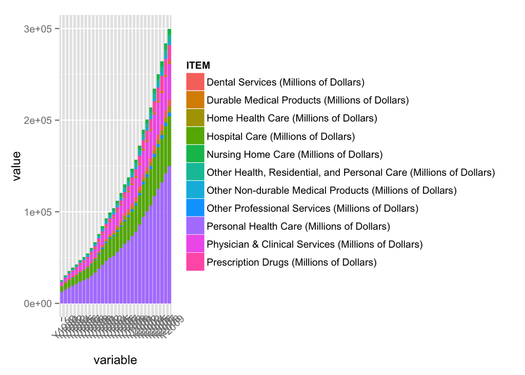

```r
source("../03 R SQL Visualizations/Bar Chart.R", echo = TRUE)
```

This chart perfectly captures the rising costs of healthcare in Texas, and more broadly, the United States (we can infer this because of the previous crosstab; Texas’s annual percentage growth numbers are very similar to those of the other states, so their expenditures can be expected to have grown at a similar rate). The cost rise is fairly uniform across items. In other words, the relative composition by item of each of the bars remains relatively the same from 1980-2009. Therefore, we conclude that, with a few exceptions, US healthcare costs rose uniformly by item from 1980-2009. If anything, the overall rate of growth accelerated in the 2000s. For future consideration and if data is available, it would be interesting to see how this trend has changed with the institution of Obamacare.

### Visualization 3: Scatterplot

This scatterplot has Hospital Care expenditures (represented here as Y1999) for the y-axis and number of deaths for the x-axis. The data points represent each of the 50 states, plus the null value for US territories. We filtered to reduce the scope and improve the graph’s readability by only showing data from the year 1999 and causes of death related to heart disease.

```
##
## > df1 <- COD %>% select(CAUSE_NAME, STATE, YEAR, DEATHS,
## +     AADR) %>% filter(YEAR == "1999", CAUSE_NAME == "Diseases of Heart",
## +     STATE != "U ..." ... [TRUNCATED]
##
## > df2 <- NHCE %>% select(ITEM, Y1999, STATE_NAME) %>%
## +     filter(ITEM == "Hospital Care (Millions of Dollars)", STATE_NAME !=
## +         "United St ..." ... [TRUNCATED]
##
## > df3 <- inner_join(df1, df2, by = c(STATE = "STATE_NAME"))
```

```
##
## > df3 %>% ggplot(aes(x = DEATHS, y = Y1999)) + geom_point() +
## +     geom_smooth(method = lm)
```

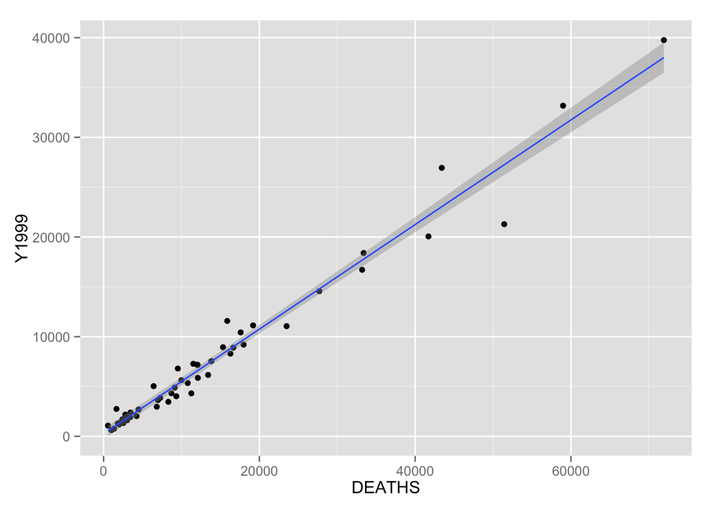

```
##
## > lm(Y1999 ~ DEATHS, df3)
##
## Call:
## lm(formula = Y1999 ~ DEATHS, data = df3)
##
## Coefficients:
## (Intercept)       DEATHS
##    256.7220       0.5247
```

```r
source("../03 R SQL Visualizations/Scatterplot.R", echo = TRUE)
```

From viewing the scatterplot, associated trendline, and associated confidence interval lines. we see that there is a clear positive correlation between heart disease deaths and hospital care expenditures. This is expected, as both statistics are likely caused by a third variable, state population. We expect that similar positive correlations will exist regardless of the filters we place on state, cause of death, and expenditure item because of the results of the prior Crosstab and Bar Chart. These results showed that healthcare expenditures are relatively homogeneous across states and expenditure items. For the most part, they rose everywhere from 1980 - 2009. This is likely why the Obama administration has been so adamant about standardizing health care policy across the United States, and not having it vary by state or expenditure item. Therefore, our analysis and above charts help explain why Obamacare has grown to cover policy at a comprehensive federal level.

### Visualization 4: Blending to find Healthcare Expenditure per Capita by State in 2009

This bar chart has healthcare expenditures per capita by state and region in the United States in 2009. First, we created the visualization in R below.

```r
source("../03 R SQL Visualizations/Blending.R", echo = TRUE)
```

```
##
## > df1 <- NHCE %>% select(STATE_NAME, Y2009, REGION_NAME) %>%
## +     filter(STATE_NAME != "null") %>% group_by(STATE_NAME, REGION_NAME) %>%
## +     summ .... [TRUNCATED]
##
## > df2 <- state_pop %>% select(STATE, NINE) %>% filter(STATE %in%
## +     c("Source: ", "Puerto Rico") == FALSE, NINE != "null")
##
## > df <- dplyr::full_join(df1, df2, by = "STATE")
```

```
##
## > df <- df %>% select(STATE, REGION_NAME, Y2009, NINE) %>%
## +     mutate(HC_exp_capita = as.numeric(as.character(1e+06 * as.numeric(as.character(Y2009 .... [TRUNCATED]
##
## > ggplot(df, aes(x = reorder(STATE, HC_exp_capita),
## +     y = HC_exp_capita, fill = REGION_NAME)) + labs(title = "Healthcare Expenditures per Capita  ..." ... [TRUNCATED]
```

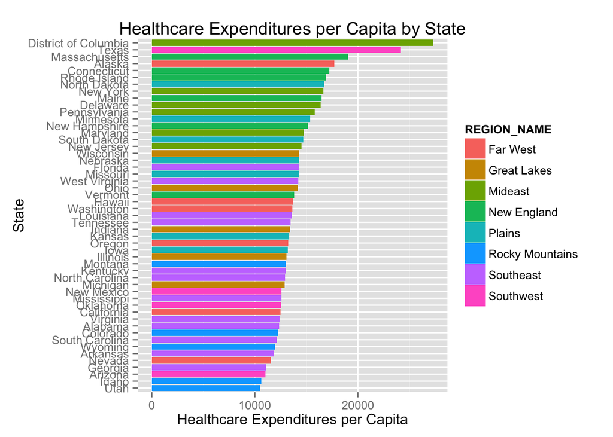

Then, we created the visualization in Tableau, shown below. You can find the worksheet in the twbx file in the 02 Tableau folder.

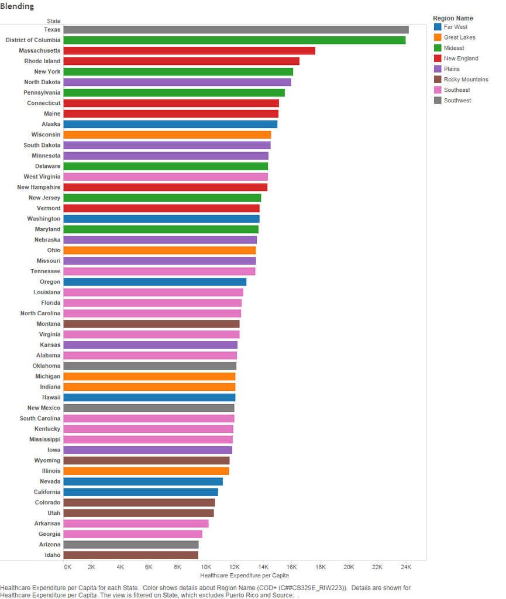

As you can see, the two most expensive healthcare states are Texas and DC. Also, the Mideast and New England generally have higher healthcare expenditures per individual, while the Southeast, Southwest, and Rocky Mountains have the lower healthcare expenditures.